# Visualización de datos con ggplot2 - Parte 2

## ¿Qué veremos en la sesión de hoy?

- Uso de funciones con ggplot2.
- Histograma
- Gráfico de cajas (boxplot)
- Diagrama de dispersión (scatterplot)

## Funciones con ggplot2

Como hemos visto en la sesión pasada, el uso de funciones es una gran herramienta para la creación de nuestros propios comandos para repetir varias veces la misma operación, sea esta la aplicación de una formula o la repeteción de un conjunto de pasos.

Un uso práctico de las funciones es la producción de gráficas o visualizaciones. En muchas ocasiones, queremos usar el mismo gráfico o gráficos similares con diferentes variables. En lugar de repetir el mismo código una y otra vez (lo que es propoenso a errores), podemos crear una función con los comandos para nuestro gráfico.

## Veamos un ejemplo práctico

```r
# Cargamos librerias
library(dplyr)
library(ggplot2)
library(janitor)

# Cargamos data de censo de salud de la municipalidad de San Borja
censo_salud <- read.csv("censo_salud_sb.csv") |>
  clean_names()
```

## Miramos nuestros datos

```r
str(censo_salud)
```

```
## 'data.frame':    50494 obs. of  44 variables:
##  $ fecha_corte             : int  20221020 20221020 20221020 20221020 20221020 20221020 20221020 20221020 20221020 20221020 ...
##  $ fecha_hora              : int  20200428 20200429 20200429 20200429 20200429 20200428 20200429 20200429 20200430 20200507 ...
##  $ departamento            : chr  "LIMA" "LIMA" "LIMA" "LIMA" ...
##  $ provincia               : chr  "LIMA" "LIMA" "LIMA" "LIMA" ...
##  $ distrito                : chr  "SAN BORJA" "SAN BORJA" "SAN BORJA" "SAN BORJA" ...
##  $ ubigeo                  : int  150130 150130 150130 150130 150130 150130 150130 150130 150130 150130 ...
##  $ ocupacion_predio        : chr  "Vivienda ocupada con personas presentes" "Vivienda ocupada con personas presentes" "Vivienda ocupada con personas presentes" "Vivienda ocupada con personas presentes" ...
##  $ tipo_vivienda           : chr  "Casa independiente" "Casa independiente" "Casa independiente" "Habitación o Departamento independiente en edificio familiar" ...
##  $ tenencia_vivienda       : chr  "Propia totalmente pagada" "Propia totalmente pagada" "Propia totalmente pagada" "Propia pagándola a plazos" ...
##  $ piso_vivienda           : chr  "Laminas asfálticas, vinílicos o similares" "Parquet o madera pulida" "Parquet o madera pulida" "Laminas asfálticas, vinílicos o similares" ...
##  $ techo_vivienda          : chr  "Ladrillo/Concreto armado" "Ladrillo/Concreto armado" "Ladrillo/Concreto armado" "Ladrillo/Concreto armado" ...
##  $ agua_vivienda           : chr  "Caño de agua conectado a red pública dentro de su vivienda" "Caño de agua conectado a red pública dentro de su vivienda" "Caño de agua conectado a red pública dentro de su vivienda" "Caño de agua conectado a red pública dentro de su vivienda" ...
##  $ servicio_higienico      : chr  "Baño conectado a desagüe dentro de su vivienda" "Baño conectado a desagüe dentro de su vivienda" "Baño conectado a desagüe dentro de su vivienda" "Baño conectado a desagüe dentro de su vivienda" ...
##  $ cantidad_hogares        : int  0 0 0 0 0 0 0 0 0 0 ...
```

[output cut: 30 more lines]

Tenemos 50 494 observaciones y 44 variables. Veamos cuantos casos tenemos por sexo

```r
tabla_sexo <- count(censo_salud, sexo)
str(tabla_sexo)
```

```
## 'data.frame':    3 obs. of  2 variables:
##  $ sexo: chr  "" "Femenino" "Masculino"
##  $ n   : int  627 27532 22335
```

Tenemos tres categorias, femenino, masculino e indeterminado.

## Gráfico de torta

## Creando una función con ggplot2

Crear una función con ggplot2 es igual que crear cualquier función. Creemos una función para un gráfico de torta

```r
grafico_torta <- function(dataset, grupos, valores) {
  ggplot(dataset, aes(x = "", y = {{ valores }}, fill = {{ grupos }})) +
    geom_bar(stat = "identity", width = 1) +
    coord_polar("y", start = 0) +
    theme_void()
}
```

## Probemos nuestra función

Como nuestra función produce un ggplot2, podemos seguir aumentando capas usando el operador `+`.

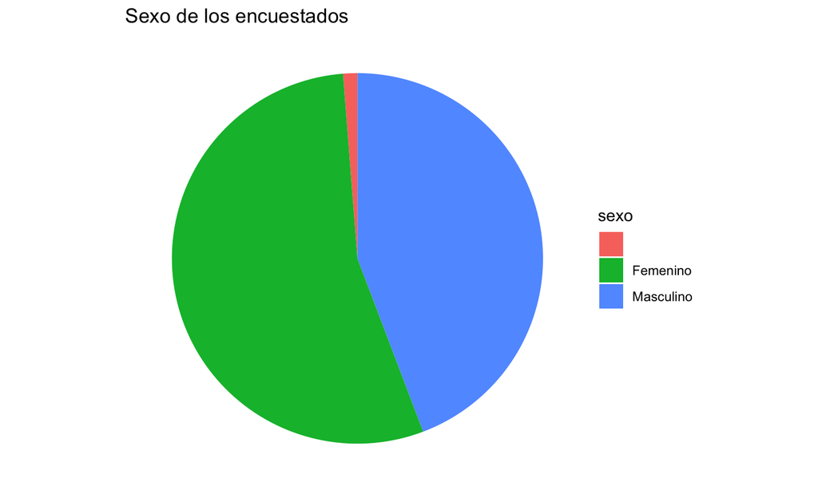

```r
grafico_torta(tabla_sexo, sexo, n) +
  labs(title = "Sexo de los encuestados")
```

## Histograma

## ¿Qué es un histograma?

Aunque se asemeja a un gráfico de barras, un histograma es una representación de la distribución de una variable numérica. En un gráfico de barras, las columnas se suelen representar separadas unas de otras, para indicar que se tratan de categorías discretas. En cambio, un histograma se representan juntas, para indicar que es una variable continua. Adicionalmente se puede agregar una curva normal sobre el mismo.

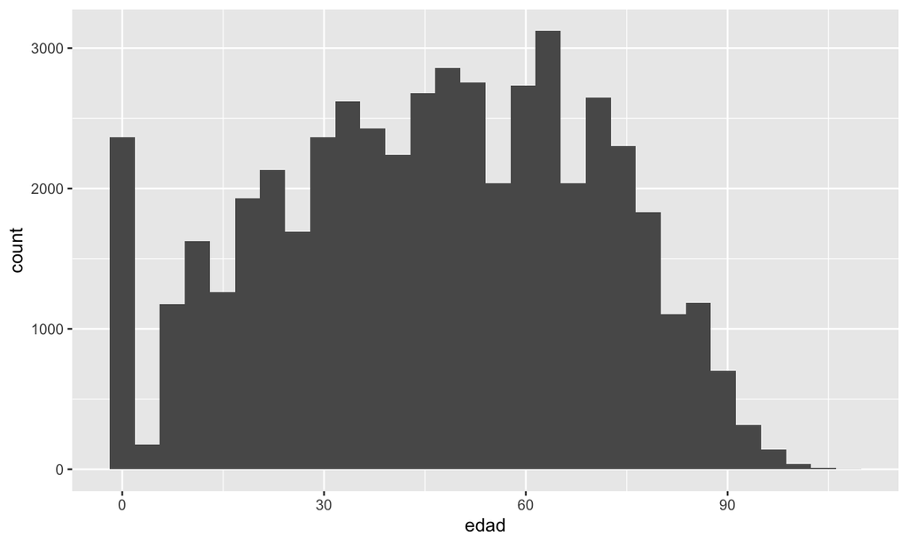

```r
# Histograma simple
ggplot(censo_salud, aes(x = edad)) +
  geom_histogram()
```

## Agregando opciones

Al igual que con otros tipos de gráficos, podemos agregar opciones para los colores y bordes

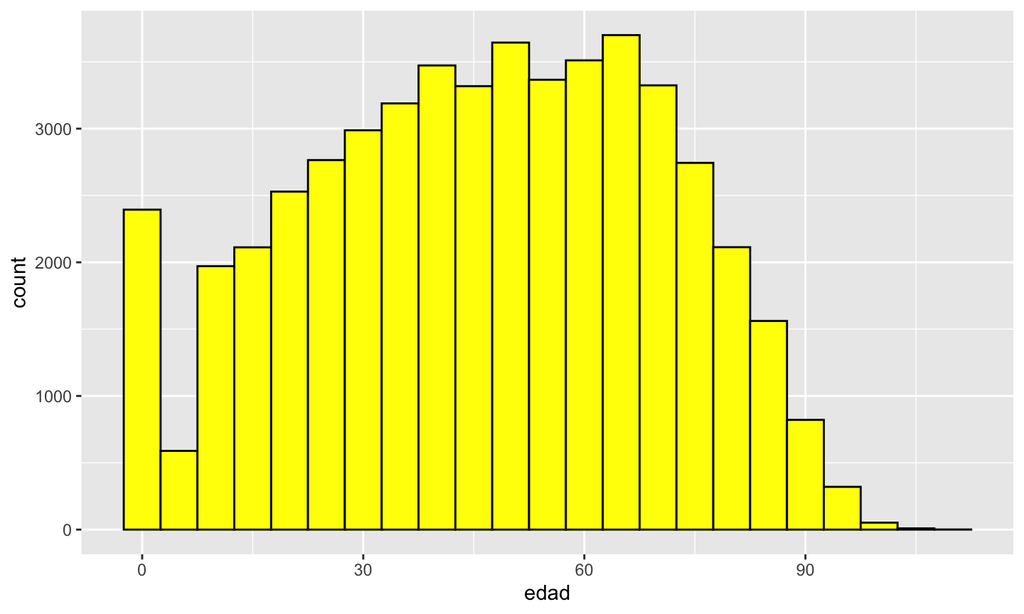

```r
ggplot(censo_salud, aes(x = edad)) +
  geom_histogram(
    binwidth = 5, # Ancho de columna en la unidad de la variable
    fill = "yellow", # color de relleno
    color = "black" # color de borde
  )
```

## Guardamos nuestro comando en una función

```r
histograma <- function(dataset, variable, binwidth = NULL) { # Creamos un valor por defecto para binwith
  ggplot(dataset, aes(x = {{ variable }})) +
    geom_histogram(
      binwidth = {{ binwidth }},
      fill = "yellow", # color de relleno
      color = "black" # color de borde
    )
}
```

## Probamos nuestra función

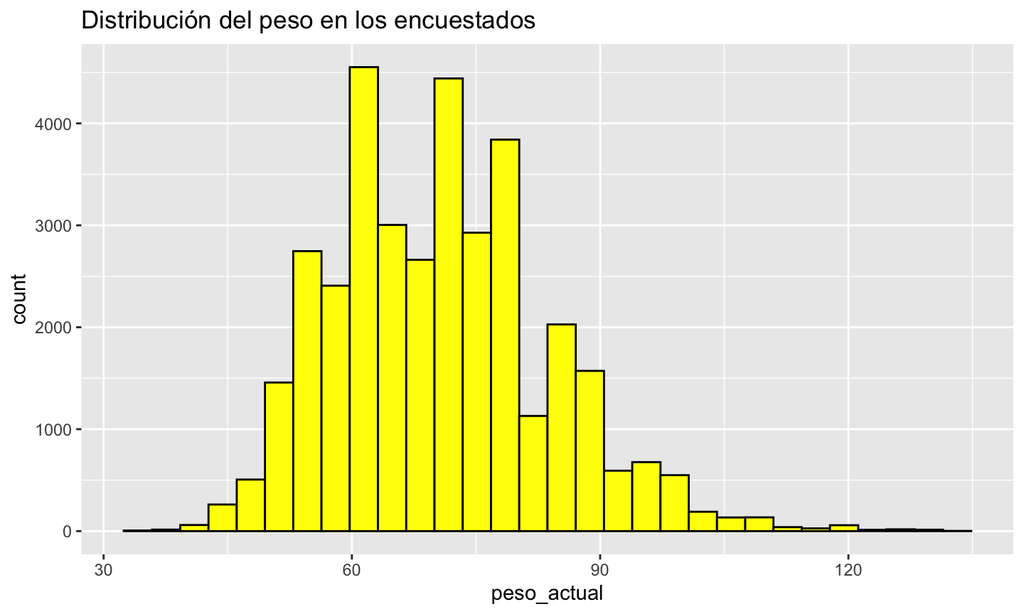

```r
histograma(censo_salud, peso_actual) +
  labs(title = "Distribución del peso en los encuestados")
```

## Probamos en otra variable numérica

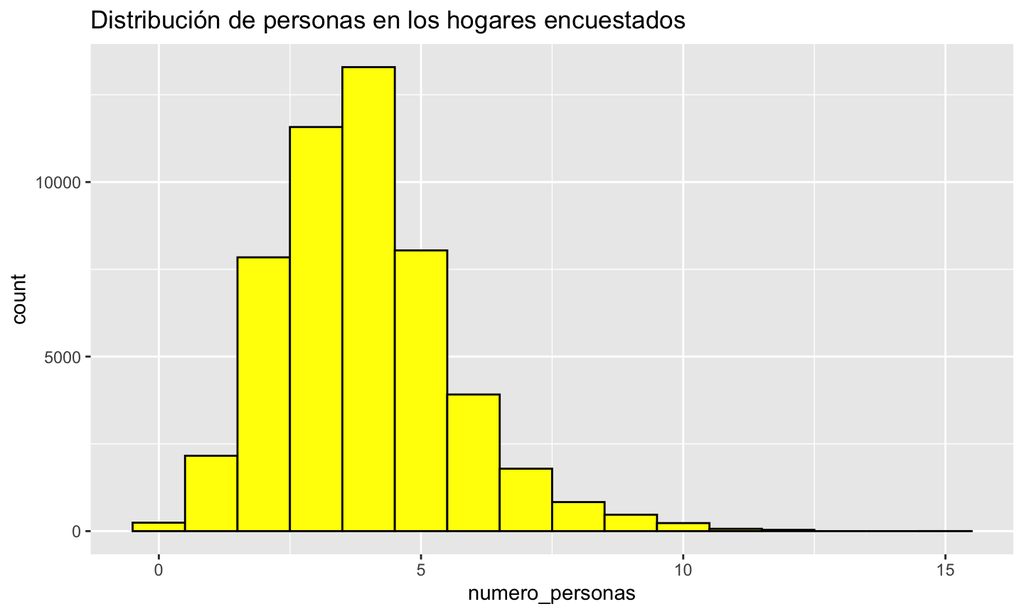

```r
histograma(censo_salud, numero_personas, 1) +
  labs(title = "Distribución de personas en los hogares encuestados")
```

## Boxplot usando ggplot2

El boxplot más simple lo creamos agregando el comando `geom_boxplot()` a nuestro ggplot2.

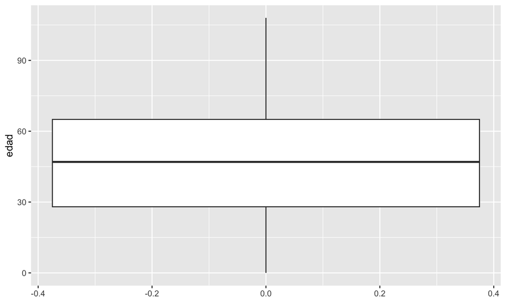

```r
ggplot(censo_salud, aes(y = edad)) +
  geom_boxplot()
```

## Separando grupos

El boxplot por lo general es bastante usado para comparar una misma variable en grupos diferentes. Por ejemplo, dividamos las edades por sexo

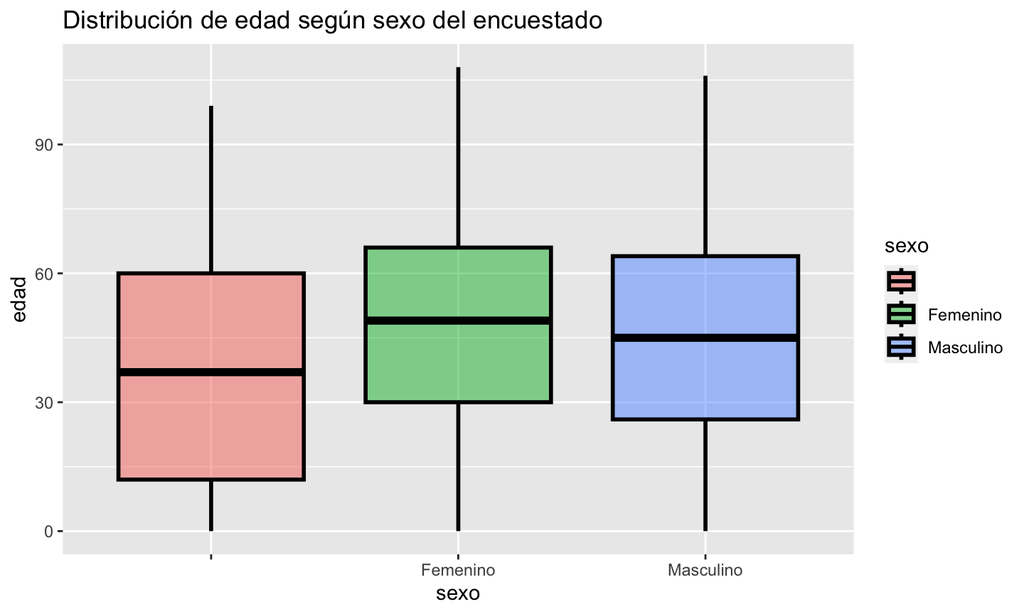

```r
ggplot(censo_salud, aes(y = edad, x = sexo, fill = sexo)) +
  geom_boxplot( # agregamos algunas opciones de colores
    color = "black",
    linewidth = 1,
    alpha = 0.5
  ) +
  labs(title = "Distribución de edad según sexo del encuestado")
```

## Diagrama de dispersión (scatterplot)

## ¿Qué es un diagrama de dispersión?

Un diagrama de dispersión nos permite ver la relación entre dos variables numéricas. Esto nos permite ver si existe una correlación entre ambas. En ggplot2 creamos un scatterplot de la siguiente manera:

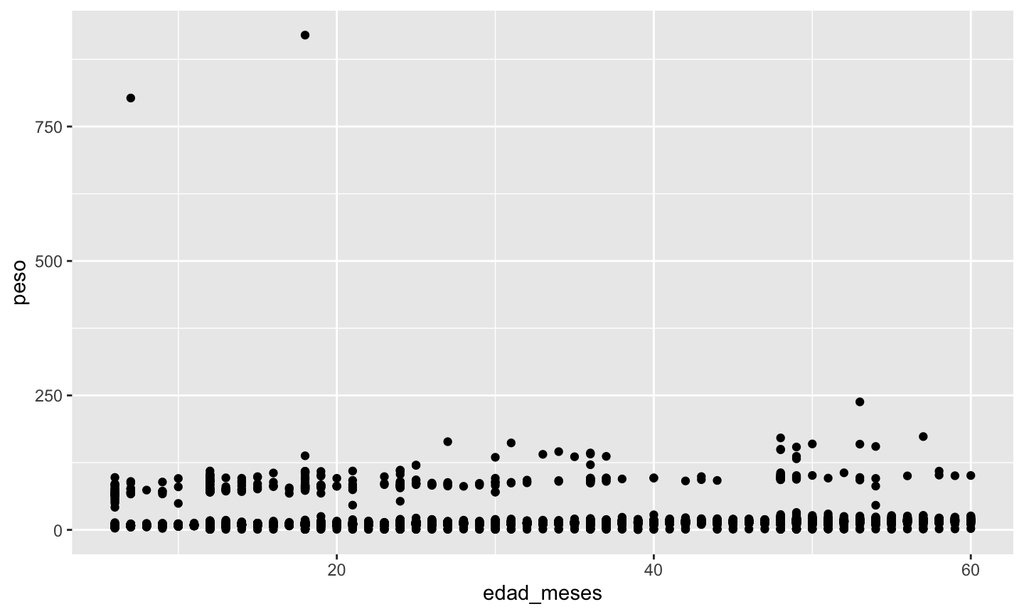

```r
# Cargaremos la data del sistema de información del estado nutricional de niños
# y gestantes para la región Cusco

ninos_cusco <- read.csv(
  "his-ninos-2021/HB_2021/Niคos CUSCO.csv"
) |>
  clean_names()

ggplot(ninos_cusco, aes(x = edad_meses, y = peso)) +
  geom_point()
```

## Eliminemos outliers de la Visualización

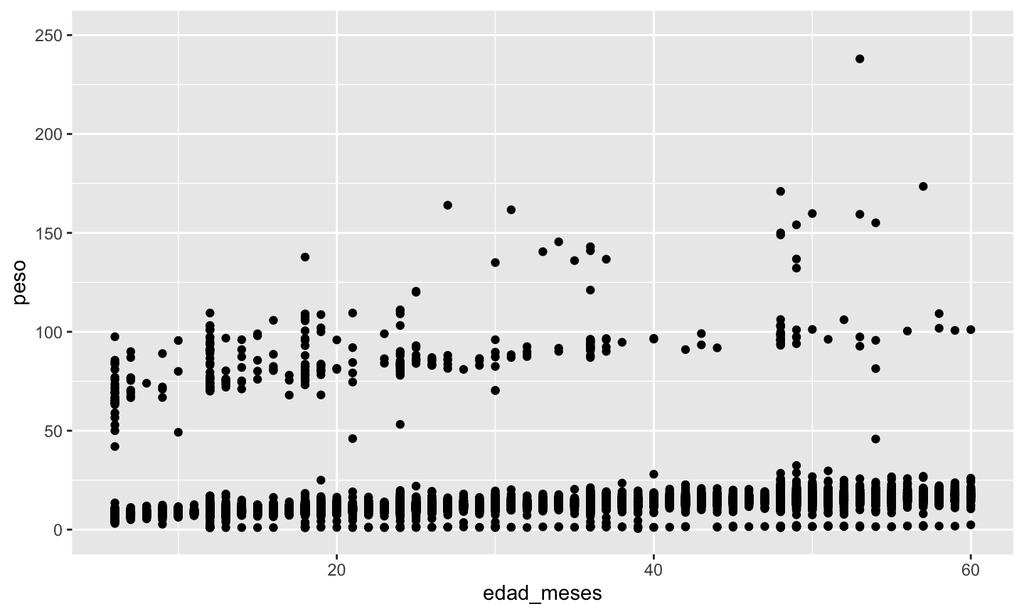

```r
ggplot(ninos_cusco, aes(x = edad_meses, y = peso)) +
  geom_point() +
  ylim(0, 250) # Definimos los límites del eje y
```

## Agregamos linea de tendencia

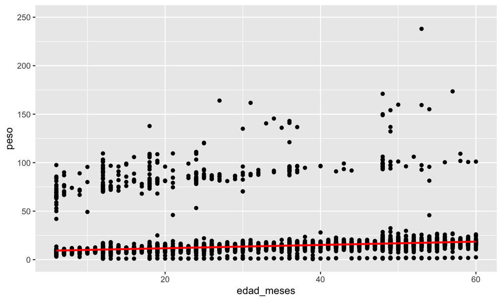

```r
ggplot(ninos_cusco, aes(x = edad_meses, y = peso)) +
  geom_point() +
  geom_smooth(method = lm, color = "red", se = FALSE) +
  ylim(0, 250)
```

## Ejercicio

Crear un gráfico de cada tipo, con una base de datos que creen o descarguen.